# StackExchange Post Exploratory Analysis by Nathan Margaglio

# Multivariate Analysis

During the multivariate analysis, I attempted to explore possible relationships between the amount of words used in the title and body of a post and the score, view count, answer count, and comment count of posts with respect to the main tags of the post.

I was unable to find any strong correlation between these variables. As a result, the only finding I can really attribute to these plots is that the amount of views, comments, answers or the score of a post is independent of the amount of words used in the title or body of the post. This is made even more apparent since it doesn’t seem to matter which language (main tag) your post is related to.

# Final Plots and Summary

### Plot One

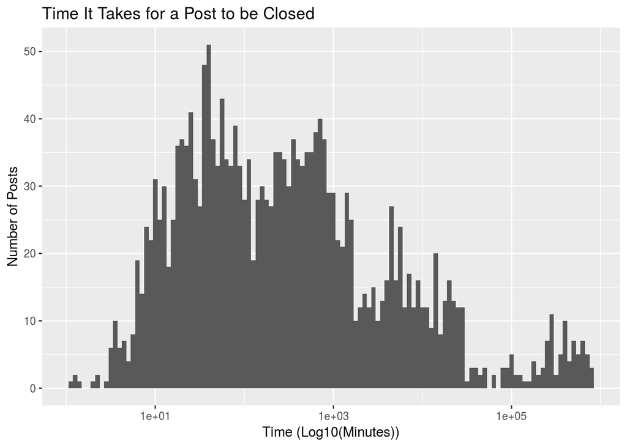

For example, if a post is created at 6:00 am on a Monday in New York, the post might not have as large an audience if it were posted a couple hours later (when users in California might be online).

Although a post being closed indiciates that there is no need for anyone else to view it for the sake of providing an answer, it does raise the question of the quality of answers given during a post’s lifespan.

### Plot Two

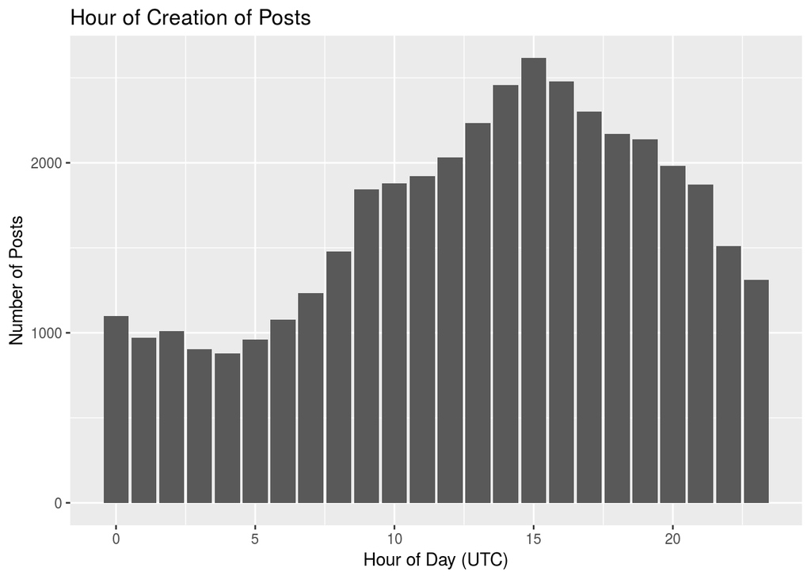

Continuing our exploration of the “life” of a typical StackExchange post, we now examine the hour of day in which these posts are created. We first note the very cyclical pattern in the above post which corresponds to a typical day for a person (i.e., most people are asleep at 3am and awake at 3pm).

We see a sudden “jump” in posts at 9am. This may correspond to roughly the time a large portion of users get to work/school and begin asking questions. When we also consider the different timezones that are accessing the site, this jump may correspond to an increase in users from different timezones for different reasons (e.g., users in New York are coming back from lunch while users in California are coming into work).

We notice the height of posts being created is at 3pm and the valley of posts being created is at 4am. This probably corresponds to the amount of people who are awake and asleep respectively.

So if posting in either one of these extremes might make a difference in the quality of answers, then we can see optimal times here. It might be the case that posting when there aren’t a lot of other new posts is ideal so that the question isn’t buried. On the other hand, it might be better to post during the peak of number of new posts since this might indicate more active users and, thus, more people looking at your post.

### Plot Three

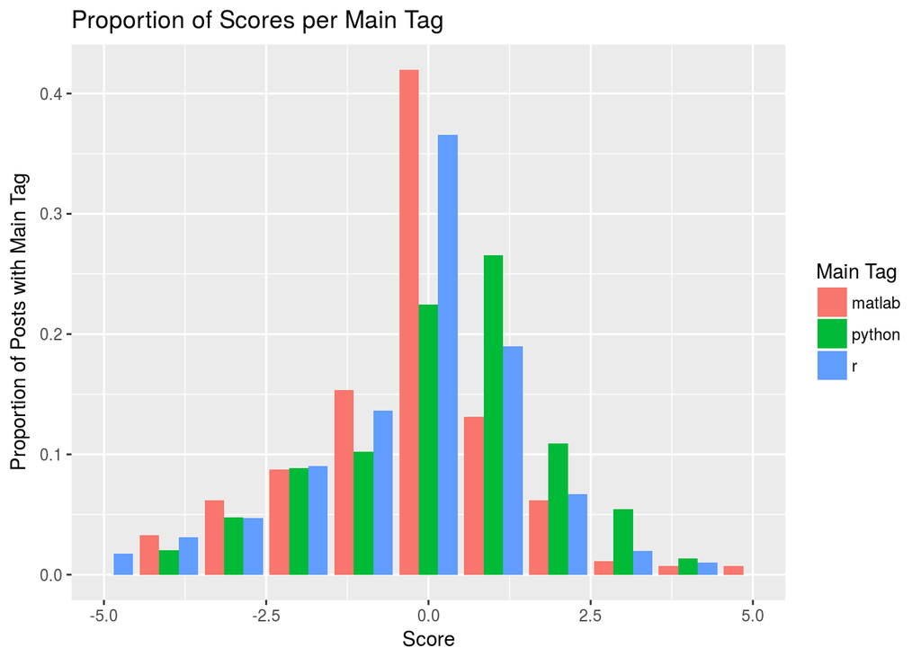

This plot now examines how different tags might affect the outcome of a post’s score. As described throughout this analysis, we can split our set of tags into three categories (matlab, python, and r) based on the tags used in the post. We then plot the proportion of posts with a specific score per main tag relative to the total number of posts with that tag. We must use proprotions here since we have signifcantly different numbers of posts with these tags, and can’t compare raw counts.

We notice that matlab posts are the most likely to have a score of 0. This might be because Matlab is the least popular of these languages, so that questions aren’t as likely to be voted on as the other two. Conversely, python posts are least likely to have a score of 0, possibly because Python is the most popular language.

Looking at positive scores, we see Python posts are much more likely to recieve high scores versus the other two languages. Matlab, on the other hand, is least likely. Looking at negative scores, we see that the three lanugages start to even out in terms of proportionality. This might indicate that “bad” posts are as likely in one language is they are in another.

# Reflection

Overall, I am not very shocked by the results of this analysis. It seems as though there aren’t very strong trends in these properties of StackExchange posts, which isn’t surprising. A post on StackExchange, or any forum for that matter, has a value based mostly in content (that is, what is said in the post).

Although we found some general trends in how posts are structure and their lifespans, there isn’t much to be said about how their structure might influence things like the post’s score or viewcount.

When examining the main tags of these posts, we did find some interesting patterns; most noteably the proportion of scores for each tag. This might be a pathway to finding which languages or topics being posted on a site like StackExchange is more popular in general, although much more analysis of many more sources would be requried to do so.

Looking forward, the next steps to properly analyzing StackExchange posts would be to analyze the content of theses posts directly. This might be done in a number of ways, such as examining the text of the body of each post more thoroughly, such as with machine learning to find sentiment or topics in a post.

In any case, StackExchange is a site full of very rich data that is ready to be explored, and this analysis, as basic as it is, shows that this is the case.